# Risk Factor Analysis

## Outcome Variable

**Outcome Variable:** stunted

## Predictor Variables

**Intervention Variable:** brthmon

**Adjustment Set:**

unadjusted

## Stratifying Variables

The analysis was stratified on these variable(s):

- agecat
- studyid

The following strata were considered:

- agecat: 12 months, studyid: ki0047075b-MAL-ED
- agecat: 12 months, studyid: ki1000108-CMC-V-BCS-2002
- agecat: 12 months, studyid: ki1000108-IRC
- agecat: 12 months, studyid: ki1000109-EE
- agecat: 12 months, studyid: ki1000109-ResPak
- agecat: 12 months, studyid: ki1000304b-SAS-FoodSuppl
- agecat: 12 months, studyid: ki1017093-NIH-Birth
- agecat: 12 months, studyid: ki1066203-TanzaniaChild2
- agecat: 12 months, studyid: ki1101329-Keneba
- agecat: 12 months, studyid: ki1112895-Guatemala BSC
- agecat: 12 months, studyid: ki1113344-GMS-Nepal
- agecat: 12 months, studyid: ki1114097-CMIN
- agecat: 12 months, studyid: ki1114097-CONTENT
- agecat: 12 months, studyid: ki1126311-ZVITAMBO
- agecat: 12 months, studyid: ki1148112-LCNI-5
- agecat: 18 months, studyid: ki0047075b-MAL-ED
- agecat: 18 months, studyid: ki1000108-CMC-V-BCS-2002
- agecat: 18 months, studyid: ki1000108-IRC
- agecat: 18 months, studyid: ki1000109-EE
- agecat: 18 months, studyid: ki1000109-ResPak
- agecat: 18 months, studyid: ki1000304b-SAS-FoodSuppl
- agecat: 18 months, studyid: ki1017093-NIH-Birth
- agecat: 18 months, studyid: ki1066203-TanzaniaChild2
- agecat: 18 months, studyid: ki1101329-Keneba
- agecat: 18 months, studyid: ki1113344-GMS-Nepal
- agecat: 18 months, studyid: ki1114097-CMIN
- agecat: 18 months, studyid: ki1114097-CONTENT
- agecat: 18 months, studyid: ki1126311-ZVITAMBO
- agecat: 18 months, studyid: ki1148112-LCNI-5
- agecat: 24 months, studyid: ki0047075b-MAL-ED
- agecat: 24 months, studyid: ki1000108-CMC-V-BCS-2002
- agecat: 24 months, studyid: ki1000108-IRC
- agecat: 24 months, studyid: ki1017093-NIH-Birth
- agecat: 24 months, studyid: ki1066203-TanzaniaChild2
- agecat: 24 months, studyid: ki1101329-Keneba
- agecat: 24 months, studyid: ki1113344-GMS-Nepal
- agecat: 24 months, studyid: ki1114097-CMIN
- agecat: 24 months, studyid: ki1114097-CONTENT
- agecat: 24 months, studyid: ki1126311-ZVITAMBO
- agecat: 24 months, studyid: ki1148112-LCNI-5
- agecat: 3 months, studyid: ki0047075b-MAL-ED
- agecat: 3 months, studyid: ki1000108-CMC-V-BCS-2002
- agecat: 3 months, studyid: ki1000108-IRC
- agecat: 3 months, studyid: ki1000109-EE
- agecat: 3 months, studyid: ki1000109-ResPak
- agecat: 3 months, studyid: ki1000304b-SAS-FoodSuppl
- agecat: 3 months, studyid: ki1017093-NIH-Birth
- agecat: 3 months, studyid: ki1066203-TanzaniaChild2
- agecat: 3 months, studyid: ki1101329-Keneba
- agecat: 3 months, studyid: ki1112895-Guatemala BSC
- agecat: 3 months, studyid: ki1113344-GMS-Nepal
- agecat: 3 months, studyid: ki1114097-CMIN
- agecat: 3 months, studyid: ki1114097-CONTENT
- agecat: 3 months, studyid: ki1126311-ZVITAMBO
- agecat: 6 months, studyid: ki0047075b-MAL-ED
- agecat: 6 months, studyid: ki1000108-CMC-V-BCS-2002
- agecat: 6 months, studyid: ki1000108-IRC
- agecat: 6 months, studyid: ki1000109-EE
- agecat: 6 months, studyid: ki1000109-ResPak
- agecat: 6 months, studyid: ki1000304b-SAS-FoodSuppl
- agecat: 6 months, studyid: ki1017093-NIH-Birth
- agecat: 6 months, studyid: ki1066203-TanzaniaChild2
- agecat: 6 months, studyid: ki1101329-Keneba
- agecat: 6 months, studyid: ki1112895-Guatemala BSC
- agecat: 6 months, studyid: ki1113344-GMS-Nepal
- agecat: 6 months, studyid: ki1114097-CMIN
- agecat: 6 months, studyid: ki1114097-CONTENT
- agecat: 6 months, studyid: ki1126311-ZVITAMBO
- agecat: 6 months, studyid: ki1148112-LCNI-5
- agecat: 9 months, studyid: ki0047075b-MAL-ED
- agecat: 9 months, studyid: ki1000108-CMC-V-BCS-2002
- agecat: 9 months, studyid: ki1000108-IRC
- agecat: 9 months, studyid: ki1000109-EE
- agecat: 9 months, studyid: ki1000109-ResPak
- agecat: 9 months, studyid: ki1000304b-SAS-FoodSuppl
- agecat: 9 months, studyid: ki1017093-NIH-Birth
- agecat: 9 months, studyid: ki1066203-TanzaniaChild2
- agecat: 9 months, studyid: ki1101329-Keneba
- agecat: 9 months, studyid: ki1112895-Guatemala BSC
- agecat: 9 months, studyid: ki1113344-GMS-Nepal
- agecat: 9 months, studyid: ki1114097-CMIN
- agecat: 9 months, studyid: ki1114097-CONTENT
- agecat: 9 months, studyid: ki1126311-ZVITAMBO
- agecat: 9 months, studyid: ki1148112-LCNI-5
- agecat: Birth, studyid: ki0047075b-MAL-ED
- agecat: Birth, studyid: ki1000108-CMC-V-BCS-2002
- agecat: Birth, studyid: ki1000108-IRC
- agecat: Birth, studyid: ki1000109-EE
- agecat: Birth, studyid: ki1000109-ResPak
- agecat: Birth, studyid: ki1017093-NIH-Birth
- agecat: Birth, studyid: ki1101329-Keneba
- agecat: Birth, studyid: ki1114097-CMIN
- agecat: Birth, studyid: ki1114097-CONTENT
- agecat: Birth, studyid: ki1126311-ZVITAMBO

### Dropped Strata

Some strata were dropped due to rare outcomes:

- agecat: 12 months, studyid: ki1000108-CMC-V-BCS-2002
- agecat: 12 months, studyid: ki1000109-EE
- agecat: 12 months, studyid: ki1000109-ResPak
- agecat: 12 months, studyid: ki1000304b-SAS-FoodSuppl
- agecat: 12 months, studyid: ki1066203-TanzaniaChild2
- agecat: 12 months, studyid: ki1112895-Guatemala BSC
- agecat: 12 months, studyid: ki1113344-GMS-Nepal
- agecat: 12 months, studyid: ki1114097-CONTENT
- agecat: 12 months, studyid: ki1148112-LCNI-5
- agecat: 18 months, studyid: ki1000108-CMC-V-BCS-2002
- agecat: 18 months, studyid: ki1000109-EE
- agecat: 18 months, studyid: ki1000109-ResPak
- agecat: 18 months, studyid: ki1000304b-SAS-FoodSuppl
- agecat: 18 months, studyid: ki1066203-TanzaniaChild2
- agecat: 18 months, studyid: ki1113344-GMS-Nepal
- agecat: 18 months, studyid: ki1114097-CONTENT
- agecat: 18 months, studyid: ki1148112-LCNI-5
- agecat: 24 months, studyid: ki1000108-CMC-V-BCS-2002
- agecat: 24 months, studyid: ki1066203-TanzaniaChild2
- agecat: 24 months, studyid: ki1113344-GMS-Nepal
- agecat: 24 months, studyid: ki1114097-CONTENT
- agecat: 24 months, studyid: ki1126311-ZVITAMBO
- agecat: 24 months, studyid: ki1148112-LCNI-5
- agecat: 3 months, studyid: ki1000108-CMC-V-BCS-2002
- agecat: 3 months, studyid: ki1000108-IRC
- agecat: 3 months, studyid: ki1000109-EE
- agecat: 3 months, studyid: ki1000109-ResPak
- agecat: 3 months, studyid: ki1000304b-SAS-FoodSuppl
- agecat: 3 months, studyid: ki1066203-TanzaniaChild2
- agecat: 3 months, studyid: ki1112895-Guatemala BSC
- agecat: 3 months, studyid: ki1113344-GMS-Nepal
- agecat: 3 months, studyid: ki1114097-CONTENT
- agecat: 6 months, studyid: ki1000109-EE
- agecat: 6 months, studyid: ki1000109-ResPak
- agecat: 6 months, studyid: ki1000304b-SAS-FoodSuppl
- agecat: 6 months, studyid: ki1066203-TanzaniaChild2
- agecat: 6 months, studyid: ki1112895-Guatemala BSC
- agecat: 6 months, studyid: ki1113344-GMS-Nepal
- agecat: 6 months, studyid: ki1114097-CONTENT
- agecat: 9 months, studyid: ki1000108-CMC-V-BCS-2002
- agecat: 9 months, studyid: ki1000109-EE
- agecat: 9 months, studyid: ki1000109-ResPak
- agecat: 9 months, studyid: ki1000304b-SAS-FoodSuppl
- agecat: 9 months, studyid: ki1066203-TanzaniaChild2
- agecat: 9 months, studyid: ki1112895-Guatemala BSC
- agecat: 9 months, studyid: ki1113344-GMS-Nepal
- agecat: 9 months, studyid: ki1114097-CONTENT
- agecat: 9 months, studyid: ki1148112-LCNI-5
- agecat: Birth, studyid: ki1000108-CMC-V-BCS-2002
- agecat: Birth, studyid: ki1000108-IRC
- agecat: Birth, studyid: ki1000109-EE
- agecat: Birth, studyid: ki1000109-ResPak
- agecat: Birth, studyid: ki1017093-NIH-Birth
- agecat: Birth, studyid: ki1101329-Keneba
- agecat: Birth, studyid: ki1114097-CMIN
- agecat: Birth, studyid: ki1114097-CONTENT

## Methods Detail

We’re interested in the causal parameters $E[Y_a]$ for all values of $a \in \mathcal{A}$. These parameters represent the mean outcome if, possibly contrary to fact, we intervened to set all units to have $A=a$. Under the randomization and positivity assumptions, these are identified by the statistical parameters $\psi_a=E_W[E_{Y|A,W}(Y|A=a,W)]$. In addition, we’re interested in the mean of $Y$, $E[Y]$ under no intervention (the observed mean). We will estimate these parameters by using SuperLearner to fit the relevant likelihood factors – $E_{Y|A,W}(Y|A=a,W)$ and $p(A=a|W)$, and then updating our likelihood fit using a joint TMLE.

For unadjusted analyses ($W=\{\}$), initial likelihoods were estimated using Lrnr_glm to estimate the simple $E(Y|A)$ and Lrnr_mean to estimate $p(A)$. For adjusted analyses, a small library containing Lrnr_glmnet, Lrnr_xgboost, and Lrnr_mean was used.

Having estimated these parameters, we will then use the delta method to estimate relative risks and attributable risks relative to a prespecified baseline level of $A$.

# Results Detail

## Results Plots

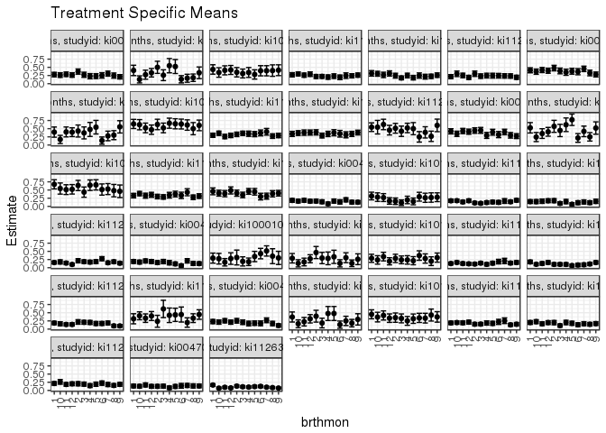

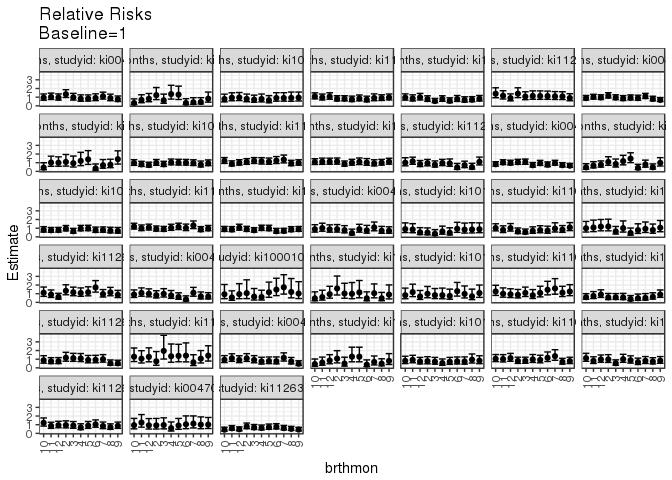

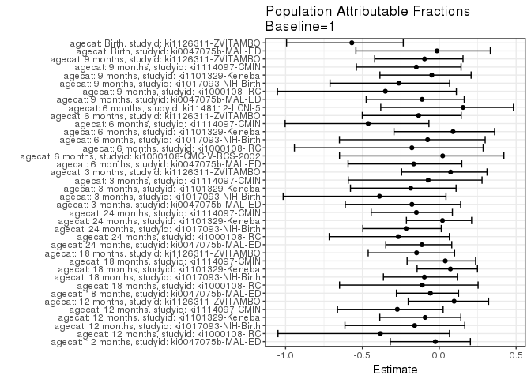

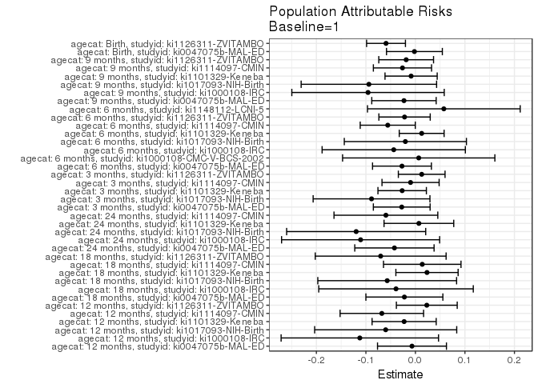

## Data Summary

| agecat | studyid | A | n | nA | nAY0 | nAY1 |
| --- | --- | --- | --- | --- | --- | --- |
| 12 months | ki0047075b-MAL-ED | 1 | 1616 | 159 | 115 | 44 |
| 12 months | ki0047075b-MAL-ED | 2 | 1616 | 143 | 90 | 53 |
| 12 months | ki0047075b-MAL-ED | 3 | 1616 | 125 | 91 | 34 |
| 12 months | ki0047075b-MAL-ED | 4 | 1616 | 105 | 81 | 24 |
| 12 months | ki0047075b-MAL-ED | 5 | 1616 | 121 | 93 | 28 |
| 12 months | ki0047075b-MAL-ED | 6 | 1616 | 103 | 77 | 26 |
| 12 months | ki0047075b-MAL-ED | 7 | 1616 | 140 | 97 | 43 |
| 12 months | ki0047075b-MAL-ED | 8 | 1616 | 113 | 85 | 28 |
| 12 months | ki0047075b-MAL-ED | 9 | 1616 | 143 | 113 | 30 |
| 12 months | ki0047075b-MAL-ED | 10 | 1616 | 145 | 107 | 38 |
| 12 months | ki0047075b-MAL-ED | 11 | 1616 | 164 | 117 | 47 |
| 12 months | ki0047075b-MAL-ED | 12 | 1616 | 155 | 114 | 41 |
| 12 months | ki1000108-CMC-V-BCS-2002 | 1 | 368 | 34 | 17 | 17 |
| 12 months | ki1000108-CMC-V-BCS-2002 | 2 | 368 | 16 | 4 | 12 |
| 12 months | ki1000108-CMC-V-BCS-2002 | 3 | 368 | 31 | 16 | 15 |
| 12 months | ki1000108-CMC-V-BCS-2002 | 4 | 368 | 43 | 22 | 21 |
| 12 months | ki1000108-CMC-V-BCS-2002 | 5 | 368 | 36 | 16 | 20 |
| 12 months | ki1000108-CMC-V-BCS-2002 | 6 | 368 | 37 | 17 | 20 |
| 12 months | ki1000108-CMC-V-BCS-2002 | 7 | 368 | 38 | 20 | 18 |
| 12 months | ki1000108-CMC-V-BCS-2002 | 8 | 368 | 18 | 12 | 6 |
| 12 months | ki1000108-CMC-V-BCS-2002 | 9 | 368 | 20 | 14 | 6 |
| 12 months | ki1000108-CMC-V-BCS-2002 | 10 | 368 | 29 | 16 | 13 |
| 12 months | ki1000108-CMC-V-BCS-2002 | 11 | 368 | 43 | 27 | 16 |
| 12 months | ki1000108-CMC-V-BCS-2002 | 12 | 368 | 23 | 4 | 19 |
| 12 months | ki1000108-IRC | 1 | 406 | 37 | 22 | 15 |
| 12 months | ki1000108-IRC | 2 | 406 | 28 | 14 | 14 |
| 12 months | ki1000108-IRC | 3 | 406 | 27 | 20 | 7 |
| 12 months | ki1000108-IRC | 4 | 406 | 20 | 9 | 11 |
| 12 months | ki1000108-IRC | 5 | 406 | 21 | 10 | 11 |
| 12 months | ki1000108-IRC | 6 | 406 | 37 | 32 | 5 |

[output cut: 1230 more lines]

## Results Table

### Parameter: TSM

| agecat | studyid | intervention_level | baseline_level | estimate | ci_lower | ci_upper |
| --- | --- | --- | --- | --- | --- | --- |
| 12 months | ki0047075b-MAL-ED | 1 | NA | 0.2767296 | 0.2071692 | 0.3462900 |
| 12 months | ki0047075b-MAL-ED | 2 | NA | 0.3706294 | 0.2914453 | 0.4498134 |
| 12 months | ki0047075b-MAL-ED | 3 | NA | 0.2720000 | 0.1939671 | 0.3500329 |
| 12 months | ki0047075b-MAL-ED | 4 | NA | 0.2285714 | 0.1482287 | 0.3089142 |
| 12 months | ki0047075b-MAL-ED | 5 | NA | 0.2314050 | 0.1562384 | 0.3065716 |
| 12 months | ki0047075b-MAL-ED | 6 | NA | 0.2524272 | 0.1685085 | 0.3363459 |
| 12 months | ki0047075b-MAL-ED | 7 | NA | 0.3071429 | 0.2307046 | 0.3835811 |
| 12 months | ki0047075b-MAL-ED | 8 | NA | 0.2477876 | 0.1681619 | 0.3274133 |
| 12 months | ki0047075b-MAL-ED | 9 | NA | 0.2097902 | 0.1430361 | 0.2765444 |
| 12 months | ki0047075b-MAL-ED | 10 | NA | 0.2620690 | 0.1904688 | 0.3336692 |
| 12 months | ki0047075b-MAL-ED | 11 | NA | 0.2865854 | 0.2173611 | 0.3558097 |
| 12 months | ki0047075b-MAL-ED | 12 | NA | 0.2645161 | 0.1950570 | 0.3339753 |
| 12 months | ki1000108-IRC | 1 | NA | 0.4054054 | 0.2470117 | 0.5637991 |
| 12 months | ki1000108-IRC | 2 | NA | 0.5000000 | 0.3145723 | 0.6854277 |
| 12 months | ki1000108-IRC | 3 | NA | 0.2592593 | 0.0937577 | 0.4247608 |
| 12 months | ki1000108-IRC | 4 | NA | 0.5500000 | 0.3316988 | 0.7683012 |
| 12 months | ki1000108-IRC | 5 | NA | 0.5238095 | 0.3099390 | 0.7376801 |
| 12 months | ki1000108-IRC | 6 | NA | 0.1351351 | 0.0248439 | 0.2454264 |
| 12 months | ki1000108-IRC | 7 | NA | 0.1666667 | 0.0447772 | 0.2885561 |
| 12 months | ki1000108-IRC | 8 | NA | 0.1818182 | 0.0677142 | 0.2959222 |
| 12 months | ki1000108-IRC | 9 | NA | 0.3333333 | 0.1553024 | 0.5113643 |
| 12 months | ki1000108-IRC | 10 | NA | 0.1315789 | 0.0239696 | 0.2391883 |
| 12 months | ki1000108-IRC | 11 | NA | 0.2750000 | 0.1364556 | 0.4135444 |
| 12 months | ki1000108-IRC | 12 | NA | 0.3333333 | 0.2037968 | 0.4628699 |
| 12 months | ki1017093-NIH-Birth | 1 | NA | 0.4347826 | 0.2913804 | 0.5781848 |
| 12 months | ki1017093-NIH-Birth | 2 | NA | 0.3488372 | 0.2062394 | 0.4914350 |
| 12 months | ki1017093-NIH-Birth | 3 | NA | 0.3111111 | 0.1757117 | 0.4465106 |
| 12 months | ki1017093-NIH-Birth | 4 | NA | 0.3421053 | 0.1911122 | 0.4930984 |
| 12 months | ki1017093-NIH-Birth | 5 | NA | 0.2820513 | 0.1406774 | 0.4234252 |
| 12 months | ki1017093-NIH-Birth | 6 | NA | 0.3947368 | 0.2391672 | 0.5503065 |

[output cut: 426 more lines]

### Parameter: E(Y)

| agecat | studyid | intervention_level | baseline_level | estimate | ci_lower | ci_upper |
| --- | --- | --- | --- | --- | --- | --- |
| 12 months | ki0047075b-MAL-ED | NA | NA | 0.2698020 | 0.2678180 | 0.2717859 |
| 12 months | ki1000108-IRC | NA | NA | 0.2931034 | 0.2800368 | 0.3061701 |
| 12 months | ki1017093-NIH-Birth | NA | NA | 0.3747454 | 0.3706487 | 0.3788421 |
| 12 months | ki1101329-Keneba | NA | NA | 0.2479466 | 0.2465399 | 0.2493533 |
| 12 months | ki1114097-CMIN | NA | NA | 0.2484157 | 0.2462210 | 0.2506104 |
| 12 months | ki1126311-ZVITAMBO | NA | NA | 0.2380952 | 0.2365984 | 0.2395921 |
| 18 months | ki0047075b-MAL-ED | NA | NA | 0.3868047 | 0.3842348 | 0.3893746 |
| 18 months | ki1000108-IRC | NA | NA | 0.3555556 | 0.3438224 | 0.3672887 |
| 18 months | ki1017093-NIH-Birth | NA | NA | 0.5874730 | 0.5814753 | 0.5934707 |
| 18 months | ki1101329-Keneba | NA | NA | 0.3224129 | 0.3206655 | 0.3241603 |
| 18 months | ki1114097-CMIN | NA | NA | 0.3542320 | 0.3527915 | 0.3556724 |
| 18 months | ki1126311-ZVITAMBO | NA | NA | 0.4752941 | 0.4651134 | 0.4854749 |
| 24 months | ki0047075b-MAL-ED | NA | NA | 0.3754197 | 0.3723985 | 0.3784410 |
| 24 months | ki1000108-IRC | NA | NA | 0.4156479 | 0.4011860 | 0.4301098 |
| 24 months | ki1017093-NIH-Birth | NA | NA | 0.5547786 | 0.5473248 | 0.5622323 |
| 24 months | ki1101329-Keneba | NA | NA | 0.3344928 | 0.3325855 | 0.3364000 |
| 24 months | ki1114097-CMIN | NA | NA | 0.4001637 | 0.3971926 | 0.4031347 |
| 3 months | ki0047075b-MAL-ED | NA | NA | 0.1552306 | 0.1538754 | 0.1565858 |
| 3 months | ki1017093-NIH-Birth | NA | NA | 0.2280702 | 0.2225262 | 0.2336141 |
| 3 months | ki1101329-Keneba | NA | NA | 0.1442922 | 0.1430334 | 0.1455511 |
| 3 months | ki1114097-CMIN | NA | NA | 0.1360269 | 0.1344378 | 0.1376161 |
| 3 months | ki1126311-ZVITAMBO | NA | NA | 0.1721708 | 0.1704645 | 0.1738772 |
| 6 months | ki0047075b-MAL-ED | NA | NA | 0.1633255 | 0.1614623 | 0.1651887 |
| 6 months | ki1000108-CMC-V-BCS-2002 | NA | NA | 0.3008130 | 0.2898222 | 0.3118038 |
| 6 months | ki1000108-IRC | NA | NA | 0.2457002 | 0.2367038 | 0.2546967 |
| 6 months | ki1017093-NIH-Birth | NA | NA | 0.2681564 | 0.2636769 | 0.2726360 |
| 6 months | ki1101329-Keneba | NA | NA | 0.1412159 | 0.1401457 | 0.1422861 |
| 6 months | ki1114097-CMIN | NA | NA | 0.1209150 | 0.1194187 | 0.1224114 |
| 6 months | ki1126311-ZVITAMBO | NA | NA | 0.1632554 | 0.1616213 | 0.1648895 |
| 6 months | ki1148112-LCNI-5 | NA | NA | 0.3717026 | 0.3637167 | 0.3796886 |
| 9 months | ki0047075b-MAL-ED | NA | NA | 0.2067073 | 0.2045726 | 0.2088420 |
| 9 months | ki1000108-IRC | NA | NA | 0.2727273 | 0.2625854 | 0.2828692 |
| 9 months | ki1017093-NIH-Birth | NA | NA | 0.3570020 | 0.3524116 | 0.3615923 |
| 9 months | ki1101329-Keneba | NA | NA | 0.1799710 | 0.1786217 | 0.1813203 |
| 9 months | ki1114097-CMIN | NA | NA | 0.1749729 | 0.1734897 | 0.1764562 |
| 9 months | ki1126311-ZVITAMBO | NA | NA | 0.1946001 | 0.1933522 | 0.1958480 |
| Birth | ki0047075b-MAL-ED | NA | NA | 0.1327552 | 0.1317987 | 0.1337117 |
| Birth | ki1126311-ZVITAMBO | NA | NA | 0.1043781 | 0.1034682 | 0.1052880 |

### Parameter: RR

| agecat | studyid | intervention_level | baseline_level | estimate | ci_lower | ci_upper |
| --- | --- | --- | --- | --- | --- | --- |
| 12 months | ki0047075b-MAL-ED | 2 | 1 | 1.3393198 | 0.9629707 | 1.8627538 |
| 12 months | ki0047075b-MAL-ED | 3 | 1 | 0.9829091 | 0.6712136 | 1.4393484 |
| 12 months | ki0047075b-MAL-ED | 4 | 1 | 0.8259740 | 0.5361601 | 1.2724429 |
| 12 months | ki0047075b-MAL-ED | 5 | 1 | 0.8362134 | 0.5545493 | 1.2609389 |
| 12 months | ki0047075b-MAL-ED | 6 | 1 | 0.9121801 | 0.6012777 | 1.3838405 |
| 12 months | ki0047075b-MAL-ED | 7 | 1 | 1.1099026 | 0.7792281 | 1.5809026 |
| 12 months | ki0047075b-MAL-ED | 8 | 1 | 0.8954143 | 0.5954429 | 1.3465049 |
| 12 months | ki0047075b-MAL-ED | 9 | 1 | 0.7581055 | 0.5053845 | 1.1372015 |
| 12 months | ki0047075b-MAL-ED | 10 | 1 | 0.9470219 | 0.6533210 | 1.3727563 |
| 12 months | ki0047075b-MAL-ED | 11 | 1 | 1.0356153 | 0.7307991 | 1.4675703 |
| 12 months | ki0047075b-MAL-ED | 12 | 1 | 0.9558651 | 0.6645491 | 1.3748842 |
| 12 months | ki1000108-IRC | 2 | 1 | 1.2333333 | 0.7196671 | 2.1136316 |
| 12 months | ki1000108-IRC | 3 | 1 | 0.6395062 | 0.3025540 | 1.3517196 |
| 12 months | ki1000108-IRC | 4 | 1 | 1.3566667 | 0.7773107 | 2.3678362 |
| 12 months | ki1000108-IRC | 5 | 1 | 1.2920635 | 0.7342713 | 2.2735849 |
| 12 months | ki1000108-IRC | 6 | 1 | 0.3333333 | 0.1348671 | 0.8238563 |
| 12 months | ki1000108-IRC | 7 | 1 | 0.4111111 | 0.1794157 | 0.9420155 |
| 12 months | ki1000108-IRC | 8 | 1 | 0.4484848 | 0.2141380 | 0.9392944 |
| 12 months | ki1000108-IRC | 9 | 1 | 0.8222222 | 0.4242262 | 1.5936061 |
| 12 months | ki1000108-IRC | 10 | 1 | 0.3245614 | 0.1311195 | 0.8033899 |
| 12 months | ki1000108-IRC | 11 | 1 | 0.6783333 | 0.3585596 | 1.2832904 |
| 12 months | ki1000108-IRC | 12 | 1 | 0.8222222 | 0.4738782 | 1.4266310 |
| 12 months | ki1017093-NIH-Birth | 2 | 1 | 0.8023256 | 0.4745021 | 1.3566353 |
| 12 months | ki1017093-NIH-Birth | 3 | 1 | 0.7155556 | 0.4144645 | 1.2353765 |
| 12 months | ki1017093-NIH-Birth | 4 | 1 | 0.7868421 | 0.4535204 | 1.3651437 |
| 12 months | ki1017093-NIH-Birth | 5 | 1 | 0.6487179 | 0.3560178 | 1.1820617 |
| 12 months | ki1017093-NIH-Birth | 6 | 1 | 0.9078947 | 0.5430574 | 1.5178376 |
| 12 months | ki1017093-NIH-Birth | 7 | 1 | 0.9078947 | 0.5430574 | 1.5178376 |
| 12 months | ki1017093-NIH-Birth | 8 | 1 | 0.9200000 | 0.5313982 | 1.5927791 |
| 12 months | ki1017093-NIH-Birth | 9 | 1 | 0.9470588 | 0.5629811 | 1.5931625 |

[output cut: 388 more lines]

### Parameter: PAR

| agecat | studyid | intervention_level | baseline_level | estimate | ci_lower | ci_upper |
| --- | --- | --- | --- | --- | --- | --- |
| 12 months | ki0047075b-MAL-ED | 1 | NA | -0.0069276 | -0.0765163 | 0.0626611 |
| 12 months | ki1000108-IRC | 1 | NA | -0.1123020 | -0.2712337 | 0.0466298 |
| 12 months | ki1017093-NIH-Birth | 1 | NA | -0.0600372 | -0.2034979 | 0.0834235 |
| 12 months | ki1101329-Keneba | 1 | NA | -0.0227716 | -0.0875350 | 0.0419917 |
| 12 months | ki1114097-CMIN | 1 | NA | -0.0678236 | -0.1521377 | 0.0164905 |
| 12 months | ki1126311-ZVITAMBO | 1 | NA | 0.0229790 | -0.0384651 | 0.0844230 |
| 18 months | ki0047075b-MAL-ED | 1 | NA | -0.0222863 | -0.1000068 | 0.0554343 |
| 18 months | ki1000108-IRC | 1 | NA | -0.0391813 | -0.1952264 | 0.1168638 |
| 18 months | ki1017093-NIH-Birth | 1 | NA | -0.0569714 | -0.1971094 | 0.0831666 |
| 18 months | ki1101329-Keneba | 1 | NA | 0.0233933 | -0.0394728 | 0.0862594 |
| 18 months | ki1114097-CMIN | 1 | NA | 0.0138064 | -0.0644448 | 0.0920577 |
| 18 months | ki1126311-ZVITAMBO | 1 | NA | -0.0701604 | -0.2023019 | 0.0619810 |
| 24 months | ki0047075b-MAL-ED | 1 | NA | -0.0423885 | -0.1224730 | 0.0376960 |
| 24 months | ki1000108-IRC | 1 | NA | -0.1106679 | -0.2702726 | 0.0489369 |
| 24 months | ki1017093-NIH-Birth | 1 | NA | -0.1196400 | -0.2600597 | 0.0207796 |
| 24 months | ki1101329-Keneba | 1 | NA | 0.0070074 | -0.0633780 | 0.0773927 |
| 24 months | ki1114097-CMIN | 1 | NA | -0.0596064 | -0.1644159 | 0.0452030 |
| 3 months | ki0047075b-MAL-ED | 1 | NA | -0.0276265 | -0.0849296 | 0.0296765 |
| 3 months | ki1017093-NIH-Birth | 1 | NA | -0.0885965 | -0.2065339 | 0.0293409 |
| 3 months | ki1101329-Keneba | 1 | NA | -0.0267604 | -0.0756653 | 0.0221445 |
| 3 months | ki1114097-CMIN | 1 | NA | -0.0098064 | -0.0674934 | 0.0478806 |
| 3 months | ki1126311-ZVITAMBO | 1 | NA | 0.0126881 | -0.0344655 | 0.0598416 |
| 6 months | ki0047075b-MAL-ED | 1 | NA | -0.0271507 | -0.0865759 | 0.0322744 |
| 6 months | ki1000108-CMC-V-BCS-2002 | 1 | NA | 0.0066954 | -0.1470624 | 0.1604531 |
| 6 months | ki1000108-IRC | 1 | NA | -0.0437734 | -0.1884262 | 0.1008793 |
| 6 months | ki1017093-NIH-Birth | 1 | NA | -0.0203051 | -0.1436386 | 0.1030284 |
| 6 months | ki1101329-Keneba | 1 | NA | 0.0126445 | -0.0326507 | 0.0579396 |
| 6 months | ki1114097-CMIN | 1 | NA | -0.0558805 | -0.1114932 | -0.0002679 |
| 6 months | ki1126311-ZVITAMBO | 1 | NA | -0.0219298 | -0.0737711 | 0.0299114 |
| 6 months | ki1148112-LCNI-5 | 1 | NA | 0.0574169 | -0.0967718 | 0.2116057 |
| 9 months | ki0047075b-MAL-ED | 1 | NA | -0.0231063 | -0.0881474 | 0.0419347 |
| 9 months | ki1000108-IRC | 1 | NA | -0.0956938 | -0.2495878 | 0.0582002 |
| 9 months | ki1017093-NIH-Birth | 1 | NA | -0.0939784 | -0.2307542 | 0.0427974 |
| 9 months | ki1101329-Keneba | 1 | NA | -0.0087083 | -0.0614053 | 0.0439887 |
| 9 months | ki1114097-CMIN | 1 | NA | -0.0261444 | -0.0848993 | 0.0326105 |
| 9 months | ki1126311-ZVITAMBO | 1 | NA | -0.0186700 | -0.0739676 | 0.0366275 |
| Birth | ki0047075b-MAL-ED | 1 | NA | -0.0019966 | -0.0583842 | 0.0543910 |
| Birth | ki1126311-ZVITAMBO | 1 | NA | -0.0593646 | -0.0985989 | -0.0201303 |

### Parameter: PAF

| agecat | studyid | intervention_level | baseline_level | estimate | ci_lower | ci_upper |
| --- | --- | --- | --- | --- | --- | --- |
| 12 months | ki0047075b-MAL-ED | 1 | NA | -0.0256765 | -0.3189368 | 0.2023785 |
| 12 months | ki1000108-IRC | 1 | NA | -0.3831479 | -1.0495118 | 0.0665592 |
| 12 months | ki1017093-NIH-Birth | 1 | NA | -0.1602079 | -0.6138221 | 0.1659041 |
| 12 months | ki1101329-Keneba | 1 | NA | -0.0918408 | -0.3869454 | 0.1404735 |
| 12 months | ki1114097-CMIN | 1 | NA | -0.2730246 | -0.6620743 | 0.0249584 |
| 12 months | ki1126311-ZVITAMBO | 1 | NA | 0.0965116 | -0.2021651 | 0.3209824 |
| 18 months | ki0047075b-MAL-ED | 1 | NA | -0.0576163 | -0.2789169 | 0.1253910 |
| 18 months | ki1000108-IRC | 1 | NA | -0.1101974 | -0.6489058 | 0.2525115 |
| 18 months | ki1017093-NIH-Birth | 1 | NA | -0.0969771 | -0.3634992 | 0.1174481 |
| 18 months | ki1101329-Keneba | 1 | NA | 0.0725569 | -0.1444287 | 0.2484017 |
| 18 months | ki1114097-CMIN | 1 | NA | 0.0389757 | -0.2093759 | 0.2363271 |
| 18 months | ki1126311-ZVITAMBO | 1 | NA | -0.1476148 | -0.4625373 | 0.0994967 |
| 24 months | ki0047075b-MAL-ED | 1 | NA | -0.1129095 | -0.3480889 | 0.0812418 |
| 24 months | ki1000108-IRC | 1 | NA | -0.2662539 | -0.7161133 | 0.0656801 |
| 24 months | ki1017093-NIH-Birth | 1 | NA | -0.2156537 | -0.4972507 | 0.0129816 |
| 24 months | ki1101329-Keneba | 1 | NA | 0.0209493 | -0.2137948 | 0.2102945 |
| 24 months | ki1114097-CMIN | 1 | NA | -0.1489552 | -0.4431711 | 0.0852797 |
| 3 months | ki0047075b-MAL-ED | 1 | NA | -0.1779710 | -0.6115613 | 0.1389619 |
| 3 months | ki1017093-NIH-Birth | 1 | NA | -0.3884615 | -1.0157914 | 0.0436384 |
| 3 months | ki1101329-Keneba | 1 | NA | -0.1854597 | -0.5778678 | 0.1093584 |
| 3 months | ki1114097-CMIN | 1 | NA | -0.0720916 | -0.5923353 | 0.2781794 |
| 3 months | ki1126311-ZVITAMBO | 1 | NA | 0.0736948 | -0.2449391 | 0.3107764 |
| 6 months | ki0047075b-MAL-ED | 1 | NA | -0.1662369 | -0.5933193 | 0.1463679 |
| 6 months | ki1000108-CMC-V-BCS-2002 | 1 | NA | 0.0222576 | -0.6490651 | 0.4202895 |
| 6 months | ki1000108-IRC | 1 | NA | -0.1781579 | -0.9426178 | 0.2854714 |
| 6 months | ki1017093-NIH-Birth | 1 | NA | -0.0757212 | -0.6496970 | 0.2985524 |
| 6 months | ki1101329-Keneba | 1 | NA | 0.0895400 | -0.2949520 | 0.3598701 |
| 6 months | ki1114097-CMIN | 1 | NA | -0.4621472 | -1.0028975 | -0.0673909 |
| 6 months | ki1126311-ZVITAMBO | 1 | NA | -0.1343284 | -0.5008376 | 0.1426782 |
| 6 months | ki1148112-LCNI-5 | 1 | NA | 0.1544700 | -0.3807422 | 0.4822199 |
| 9 months | ki0047075b-MAL-ED | 1 | NA | -0.1117829 | -0.4755302 | 0.1622935 |
| 9 months | ki1000108-IRC | 1 | NA | -0.3508772 | -1.0528190 | 0.1110423 |
| 9 months | ki1017093-NIH-Birth | 1 | NA | -0.2632434 | -0.7109859 | 0.0673307 |
| 9 months | ki1101329-Keneba | 1 | NA | -0.0483871 | -0.3861861 | 0.2070938 |
| 9 months | ki1114097-CMIN | 1 | NA | -0.1494197 | -0.5394565 | 0.1417973 |
| 9 months | ki1126311-ZVITAMBO | 1 | NA | -0.0959405 | -0.4203600 | 0.1543794 |
| Birth | ki0047075b-MAL-ED | 1 | NA | -0.0150397 | -0.5424697 | 0.3320416 |
| Birth | ki1126311-ZVITAMBO | 1 | NA | -0.5687459 | -0.9936758 | -0.2343852 |